```r
source("104964210_stats102a_hw1.R")
```

# Question 1

## a. Flowchart

[output not shown]

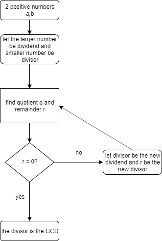

## b. Pseudocode

### gcd: start with two positive integers. First find the larger number and the smaller number. Divide the larger number by the smaller one and find the quotient and the remainder. If the remainder is 0, then the divisor is the GCD. Otherwise, let the divisor be the new dividend and remainder be the new divisor and keep dividing until the remainder is 0, after which find the last divisor which is the GCD.

### gcd2: start with three positive integers. Find the GCD of the first two numbers using gcd function. Then find the GCD of all three numbers by using gcd function again to find the GCD of the first GCD and the third number.

## c. Test

```r
gcd(1071, 462)
```

```
## [1] 21
```

```r
gcd(462, 1071)
```

```
## [1] 21
```

```r
gcd(646, 1406)
```

```
## [1] 38
```

```r
gcd(1, 10)
```

```
## [1] 1
```

```r
try(gcd(0, 12), silent = FALSE)
```

```
## Error in gcd(0, 12) : ERROR
```

```r
try(gcd(4.5, 12), silent = FALSE)
```

```
## Error in gcd(4.5, 12) : ERROR
```

```r
try(gcd(-1, 12), silent = FALSE)
```

```
## Error in gcd(-1, 12) : ERROR
```

```r
gcd_3(1071, 462, 4452)
```

```
## [1] 21
```

```r
gcd_3(646, 1406, 4218)
```

```
## [1] 38
```

# Question 2

## a. Flowchart

[output not shown]

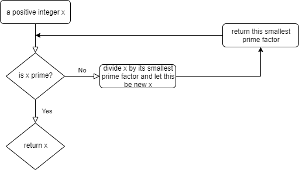

## b. Pseudocode

### get_divisors: start with a positive integer x. Create an empty vector v and an index number j = 1. Let i range from 1 to x. If the GCD between i and x is i, then i is a factor of x and we add i to v and increase j by 1. Repeat this process and return v that contain all i’s.

### is_prime: start with a positive integer x. Find v using the get_divisors function. If the length of v is 2, which means that the prime numbers has two divisors, then print TRUE. Otherwise, print FALSE.

### is_prime2: start with a positive integer x. Find v using the get_divisors function. If the length of v is 2, which means that the prime numbers has two divisors, then return TRUE. Otherwise, return FALSE.

### get_factors: start with a positive integer x. If x is prime, return x. Otherwise, divide x by its smallest prime number and let it be new x, and return this prime number. Keep doing so until x is prime, then return x.

## c. Test

```r
is_prime(9)
```

```
## [1] FALSE
```

```r
is_prime(c(2, 97, 23, 51, 118, -1, 0, 1.5))
```

```
## [1] TRUE
## [1] TRUE
## [1] TRUE
## [1] FALSE
## [1] FALSE
## [1] FALSE
## [1] FALSE
## [1] FALSE
```

```r
get_factors(12)
```

```
## [1] 2
## [1] 2
## [1] 3
```

```r
get_factors(1800)
```

```
## [1] 2
## [1] 2
## [1] 2
## [1] 3
## [1] 3
## [1] 5
## [1] 5
```

```r
get_factors(32851)
```

```
## [1] 7
## [1] 13
## [1] 19
## [1] 19
```

```r
get_factors(9587)
```

```
## [1] 9587
```

```r
try(get_factors(-280), silent = FALSE)
```

```
## Error in get_factors(-280) : ERROR
```

```r
try(get_factors(280.75), silent = FALSE)
```

```
## Error in get_factors(280.75) : ERROR
```